# Homework 1 - Data Analytics

Costanza Colauzzi, Gabriele Granzotto, Davide Zorzetto

2023-05-19

## Introduction

The dataset $\texttt{insurance.csv}$ describes the medical expenses incurred by a U.S. insurance company for 1,338 individuals. The variables present in the dataset are:

```
$\texttt{age}$: age of the insured
$\texttt{sex}$: gender of the insured
$\texttt{bmi}$: body mass index
$\texttt{children}$: number of dependents
$\texttt{smoker}$: smoker
$\texttt{region}$: the insured's region of residence in the United States
$\texttt{charges}$: individual medical charges billed by the insurance.
```

For the creation of the plots, both the base library and ‘lattice’ were used.

### a.

In the Dataset there are *four* categorial variables:

- **Sex**
- **Children**
- **Smoker**
- **Region**

These variables have been represented using **Barplots** to highlight the *relative frequency*.  
The most frequent value has been highlighted with a **red border**.

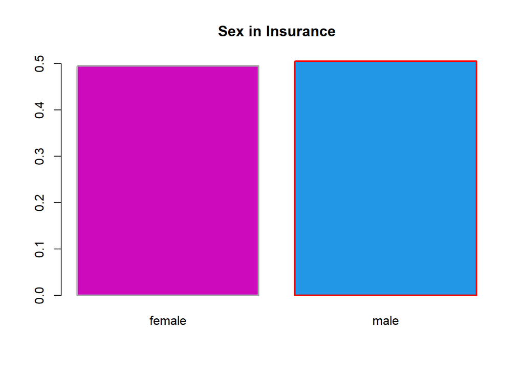

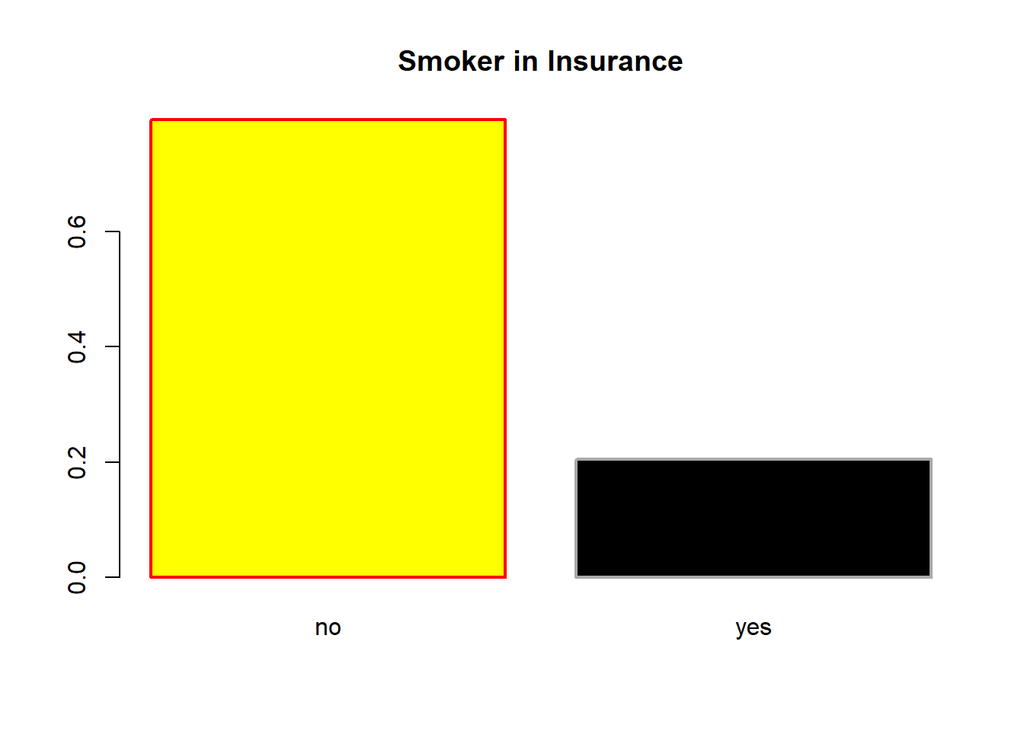

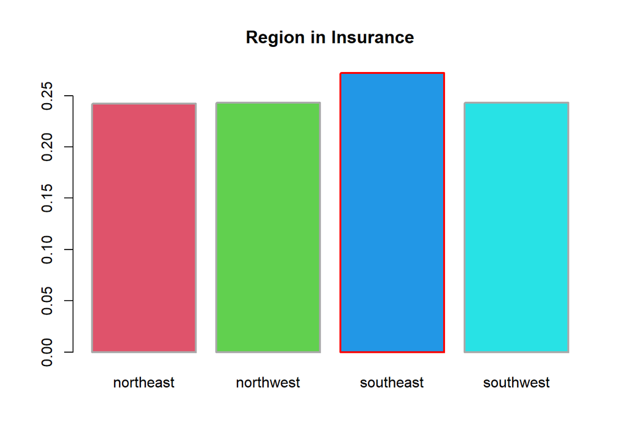

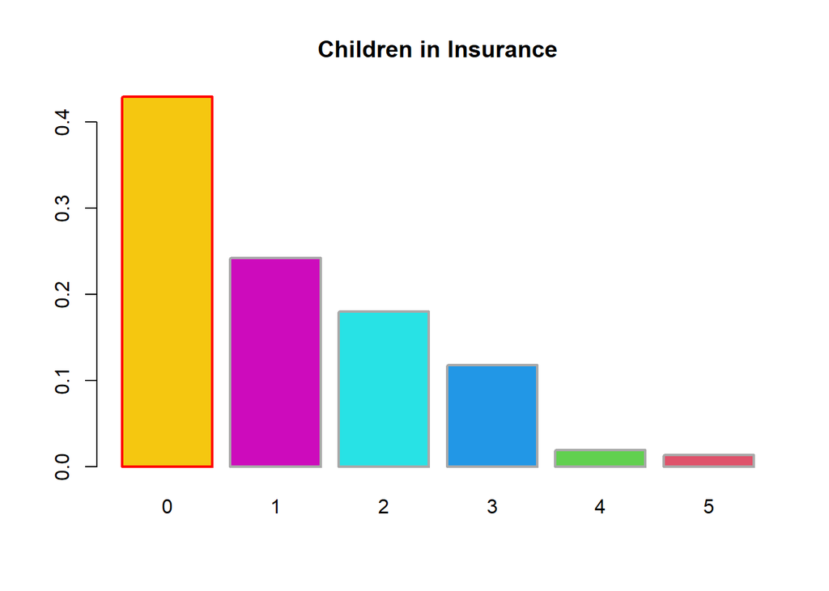

The last plot represents the number of children per individual by treating the variable ‘children’ as a category.  
Although the number of children is a numerical variable, we considered it reasonable to treat it as a categorical variable since the number of categories is limited.

### b.

The **boxplot** represents medical expenses as a function of the number of children, divided into *four categories*:

- **0**
- **1**
- **2**
- **3+**

**Red bars** were added to the *boxplot* to indicate the **mean** of the distribution.

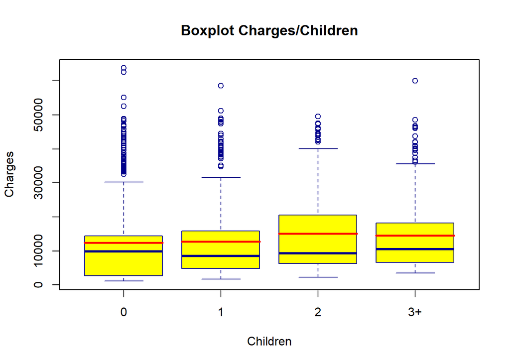

The positive difference between the **mean** and the **median**, along with the presence of outliers above the upper whisker, indicates a positively skewed distribution with a right-tailed shape for the ‘**Charges**’ variable.

### c.

Based on the **bmi** variable, a new categorical variable **catbmi** has been created with the following categories:

- **underweight** : bmi $<$ 18.5
- **normal** : 18.5 $\leq$ bmi $\leq$ 24.99
- **overweight** : 25 $\leq$ bmi $<$ 30
- **obese** : bmi $\geq$ 30

The graph was produced using the *“lattice”* library.  
After analysis, the histogram was divided into **six** bins, considered sufficient to represent the data.

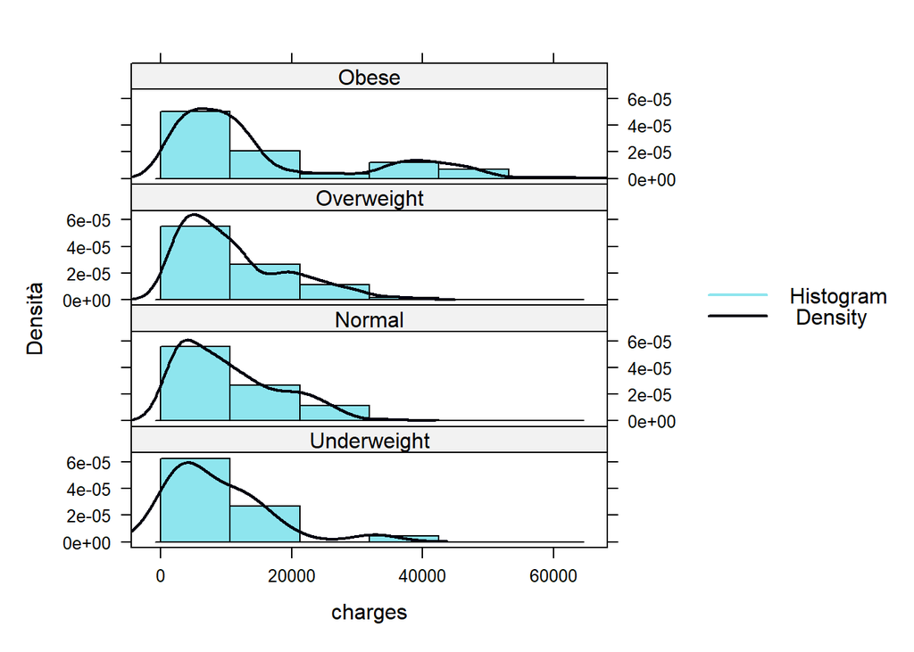

### d.

As a first graph to attempt to explore the relationship between **catbmi** and **sex**, two **side-by-side** **barplots** of the *relative frequencies* of **sex** conditional on **catbmi** were used.

```
##
##          Underweight Normal Overweight Obese
##   female          13    118        197   334
##   male             8    108        189   371
```

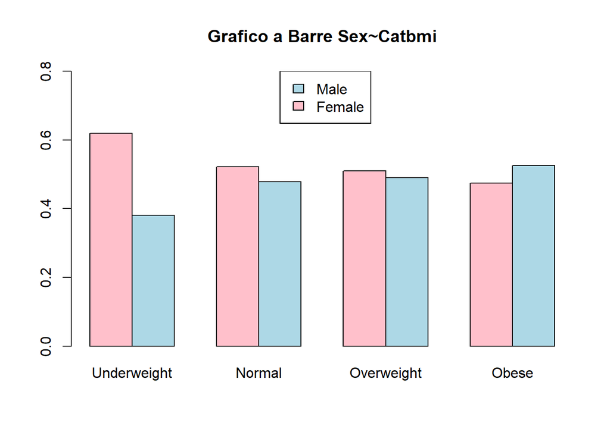

From this graph we observe that, except in the *Underweight* group, there is possible independence between *males* and *females*.  
We tried to investigate the supposed difference between males and females in the *Underweight* so we drew the graph of *relative frequencies* of **catbmi** conditioned to **sex**.

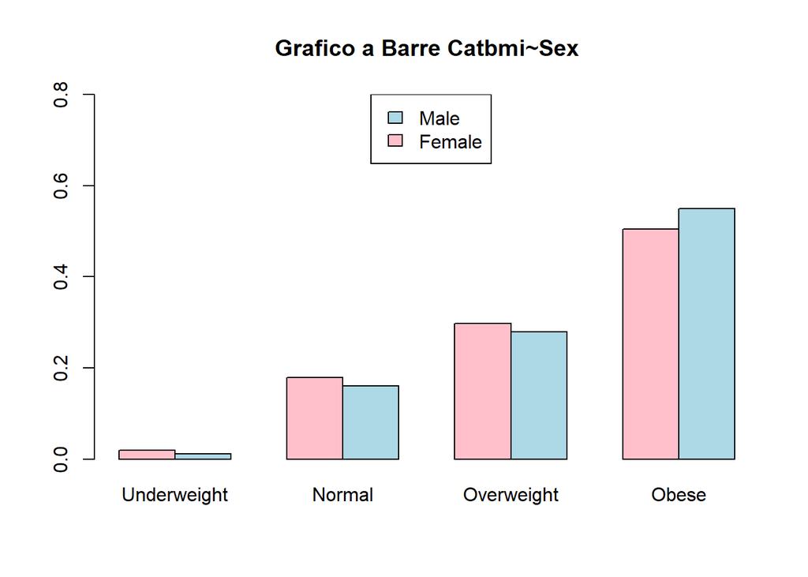

This graph shows the paucity of data from the *Underweight* category for both genders.If you see the difference in values between *males* and *females* in a **Barplot** it would seem to suggest that females are more likely to be underweight.

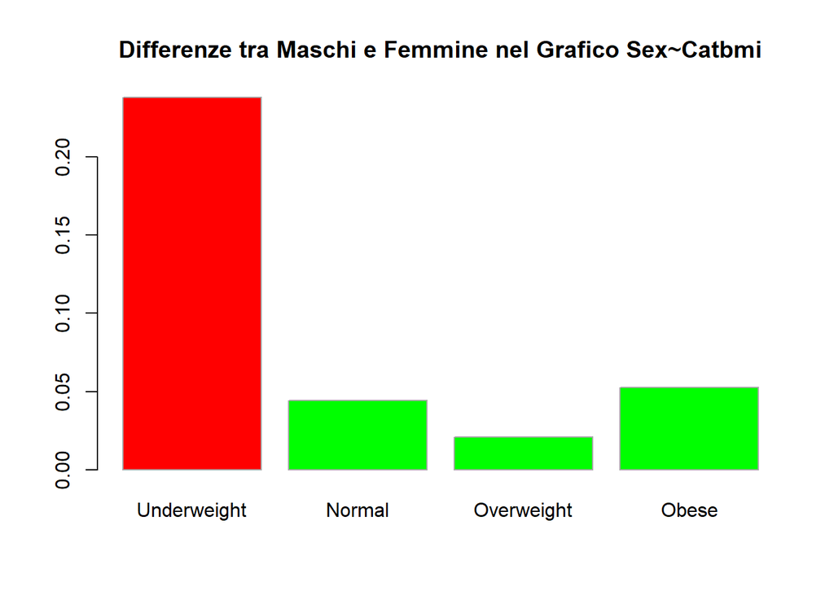

But this from the data we have cannot be inferred with certainty, since, as we can see from the chart below, the data for the **Underweight** category available to us are small in number.

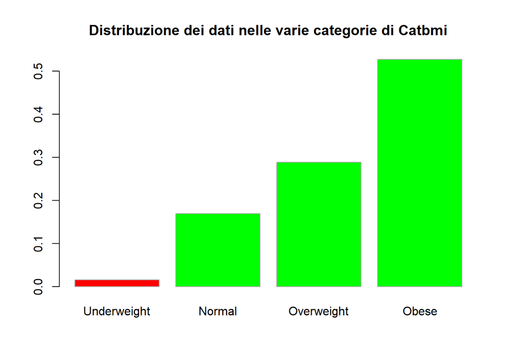

Finally, the $\chi^2$ test shows that there is little evidence against the hypothesis that the sex and bmi variables are independent, making their association unlikely.

```
##
##  Pearson's Chi-squared test
##
## data:  table.sex.bmi
## X-squared = 3.5945, df = 3, p-value = 0.3087
```

### e.

The image below consists of five graphs:

- The middle one is the **Dispersion Graph** of Medical Expenditures Relative to Age, with nonsmokers in **green** and smokers in **purple** ;
- There are two **Boxplots** representing the marginal distribution of *Medical Expenses* and *Age of the Sample*;
- There are also two **Distributions with the Core Method** of *Age* and *Medical Expenses* conditional on *Smoker* status.

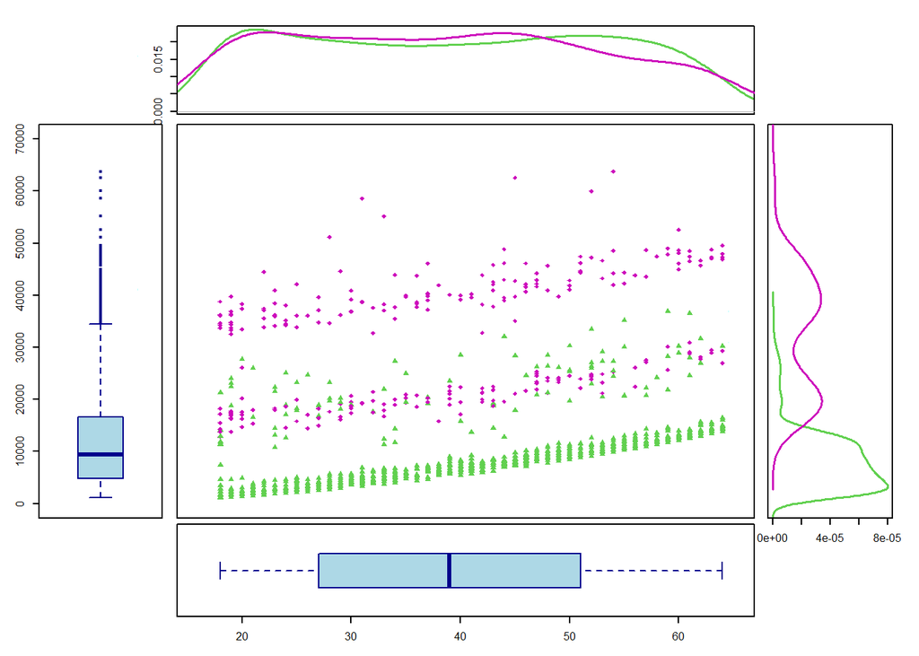